# Risk Factor Analysis

## Outcome Variable

**Outcome Variable:** co_occurence

## Predictor Variables

**Intervention Variable:** ever_sunderweight06

**Adjustment Set:**

- sex
- arm
- enstunt
- month
- brthmon
- hhwealth_quart
- W_birthwt
- W_birthlen
- W_mage
- W_mhtcm
- W_meducyrs
- W_feducyrs
- delta_month
- delta_brthmon
- delta_hhwealth_quart
- delta_W_birthwt
- delta_W_birthlen
- delta_W_mage
- delta_W_mhtcm
- delta_W_meducyrs
- delta_W_feducyrs

## Stratifying Variables

The analysis was stratified on these variable(s):

- studyid
- country

## Data Summary

| studyid | country | ever_sunderweight06 | co_occurence | n_cell | n |
| --- | --- | --- | --- | --- | --- |
| ki0047075b-MAL-ED | BANGLADESH | 0 | 0 | 199 | 221 |
| ki0047075b-MAL-ED | BANGLADESH | 0 | 1 | 11 | 221 |
| ki0047075b-MAL-ED | BANGLADESH | 1 | 0 | 8 | 221 |
| ki0047075b-MAL-ED | BANGLADESH | 1 | 1 | 3 | 221 |
| ki0047075b-MAL-ED | BRAZIL | 0 | 0 | 179 | 180 |
| ki0047075b-MAL-ED | BRAZIL | 0 | 1 | 1 | 180 |
| ki0047075b-MAL-ED | BRAZIL | 1 | 0 | 0 | 180 |
| ki0047075b-MAL-ED | BRAZIL | 1 | 1 | 0 | 180 |
| ki0047075b-MAL-ED | INDIA | 0 | 0 | 189 | 228 |
| ki0047075b-MAL-ED | INDIA | 0 | 1 | 10 | 228 |
| ki0047075b-MAL-ED | INDIA | 1 | 0 | 22 | 228 |
| ki0047075b-MAL-ED | INDIA | 1 | 1 | 7 | 228 |
| ki0047075b-MAL-ED | NEPAL | 0 | 0 | 217 | 229 |
| ki0047075b-MAL-ED | NEPAL | 0 | 1 | 2 | 229 |
| ki0047075b-MAL-ED | NEPAL | 1 | 0 | 8 | 229 |
| ki0047075b-MAL-ED | NEPAL | 1 | 1 | 2 | 229 |
| ki0047075b-MAL-ED | PERU | 0 | 0 | 211 | 222 |
| ki0047075b-MAL-ED | PERU | 0 | 1 | 4 | 222 |
| ki0047075b-MAL-ED | PERU | 1 | 0 | 5 | 222 |
| ki0047075b-MAL-ED | PERU | 1 | 1 | 2 | 222 |
| ki0047075b-MAL-ED | SOUTH AFRICA | 0 | 0 | 230 | 241 |
| ki0047075b-MAL-ED | SOUTH AFRICA | 0 | 1 | 4 | 241 |
| ki0047075b-MAL-ED | SOUTH AFRICA | 1 | 0 | 7 | 241 |
| ki0047075b-MAL-ED | SOUTH AFRICA | 1 | 1 | 0 | 241 |
| ki0047075b-MAL-ED | TANZANIA, UNITED REPUBLIC OF | 0 | 0 | 218 | 225 |
| ki0047075b-MAL-ED | TANZANIA, UNITED REPUBLIC OF | 0 | 1 | 0 | 225 |
| ki0047075b-MAL-ED | TANZANIA, UNITED REPUBLIC OF | 1 | 0 | 6 | 225 |
| ki0047075b-MAL-ED | TANZANIA, UNITED REPUBLIC OF | 1 | 1 | 1 | 225 |
| ki1000108-CMC-V-BCS-2002 | INDIA | 0 | 0 | 288 | 369 |
| ki1000108-CMC-V-BCS-2002 | INDIA | 0 | 1 | 8 | 369 |

[output cut: 102 more lines]

The following strata were considered:

- studyid: ki0047075b-MAL-ED, country: BANGLADESH
- studyid: ki0047075b-MAL-ED, country: BRAZIL
- studyid: ki0047075b-MAL-ED, country: INDIA
- studyid: ki0047075b-MAL-ED, country: NEPAL
- studyid: ki0047075b-MAL-ED, country: PERU
- studyid: ki0047075b-MAL-ED, country: SOUTH AFRICA
- studyid: ki0047075b-MAL-ED, country: TANZANIA, UNITED REPUBLIC OF
- studyid: ki1000108-CMC-V-BCS-2002, country: INDIA
- studyid: ki1000108-IRC, country: INDIA
- studyid: ki1000109-EE, country: PAKISTAN
- studyid: ki1000109-ResPak, country: PAKISTAN
- studyid: ki1000304b-SAS-CompFeed, country: INDIA
- studyid: ki1000304b-SAS-FoodSuppl, country: INDIA
- studyid: ki1017093-NIH-Birth, country: BANGLADESH
- studyid: ki1017093b-PROVIDE, country: BANGLADESH
- studyid: ki1017093c-NIH-Crypto, country: BANGLADESH
- studyid: ki1066203-TanzaniaChild2, country: TANZANIA, UNITED REPUBLIC OF
- studyid: ki1101329-Keneba, country: GAMBIA
- studyid: ki1112895-Burkina Faso Zn, country: BURKINA FASO
- studyid: ki1113344-GMS-Nepal, country: NEPAL
- studyid: ki1114097-CMIN, country: BANGLADESH
- studyid: ki1114097-CMIN, country: BRAZIL
- studyid: ki1114097-CMIN, country: GUINEA-BISSAU
- studyid: ki1114097-CMIN, country: PERU
- studyid: ki1114097-CONTENT, country: PERU
- studyid: ki1119695-PROBIT, country: BELARUS
- studyid: ki1126311-ZVITAMBO, country: ZIMBABWE
- studyid: ki1135781-COHORTS, country: GUATEMALA
- studyid: ki1135781-COHORTS, country: PHILIPPINES
- studyid: ki1148112-iLiNS-DOSE, country: MALAWI
- studyid: ki1148112-iLiNS-DYAD-M, country: MALAWI
- studyid: ki1148112-LCNI-5, country: MALAWI
- studyid: kiGH5241-JiVitA-4, country: BANGLADESH

### Dropped Strata

Some strata were dropped due to rare outcomes:

- studyid: ki0047075b-MAL-ED, country: BANGLADESH
- studyid: ki0047075b-MAL-ED, country: BRAZIL
- studyid: ki0047075b-MAL-ED, country: NEPAL
- studyid: ki0047075b-MAL-ED, country: PERU
- studyid: ki0047075b-MAL-ED, country: SOUTH AFRICA
- studyid: ki0047075b-MAL-ED, country: TANZANIA, UNITED REPUBLIC OF
- studyid: ki1000109-ResPak, country: PAKISTAN
- studyid: ki1066203-TanzaniaChild2, country: TANZANIA, UNITED REPUBLIC OF
- studyid: ki1112895-Burkina Faso Zn, country: BURKINA FASO
- studyid: ki1114097-CMIN, country: BRAZIL
- studyid: ki1114097-CMIN, country: GUINEA-BISSAU
- studyid: ki1114097-CMIN, country: PERU
- studyid: ki1114097-CONTENT, country: PERU
- studyid: ki1119695-PROBIT, country: BELARUS
- studyid: ki1148112-iLiNS-DOSE, country: MALAWI
- studyid: ki1148112-iLiNS-DYAD-M, country: MALAWI
- studyid: ki1148112-LCNI-5, country: MALAWI

## Methods Detail

We’re interested in the causal parameters $E[Y_a]$ for all values of $a \in \mathcal{A}$. These parameters represent the mean outcome if, possibly contrary to fact, we intervened to set all units to have $A=a$. Under the randomization and positivity assumptions, these are identified by the statistical parameters $\psi_a=E_W[E_{Y|A,W}(Y|A=a,W)]$. In addition, we’re interested in the mean of $Y$, $E[Y]$ under no intervention (the observed mean). We will estimate these parameters by using SuperLearner to fit the relevant likelihood factors – $E_{Y|A,W}(Y|A=a,W)$ and $p(A=a|W)$, and then updating our likelihood fit using a joint TMLE.

For unadjusted analyses ($W=\{\}$), initial likelihoods were estimated using Lrnr_glm to estimate the simple $E(Y|A)$ and Lrnr_mean to estimate $p(A)$. For adjusted analyses, a small library containing Lrnr_glmnet, Lrnr_xgboost, and Lrnr_mean was used.

Having estimated these parameters, we will then use the delta method to estimate relative risks and attributable risks relative to a prespecified baseline level of $A$.

# Results Detail

## Results Plots

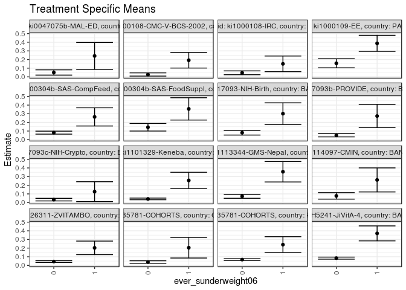

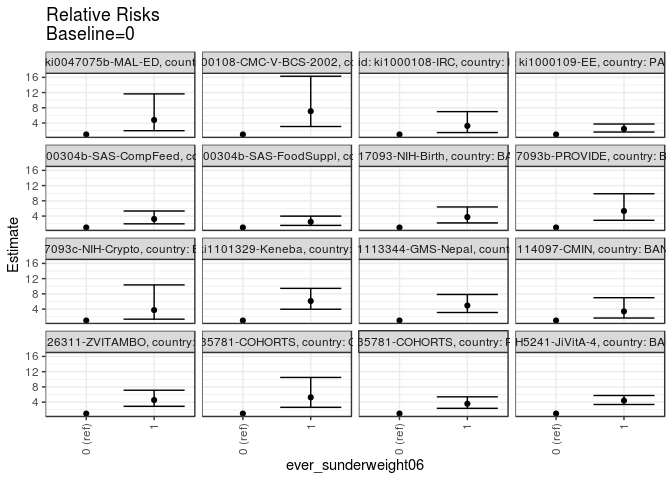

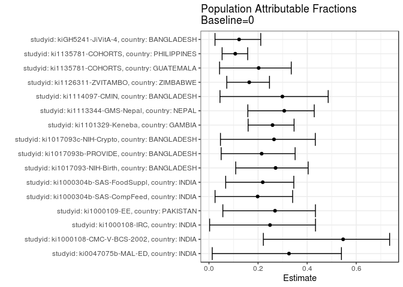

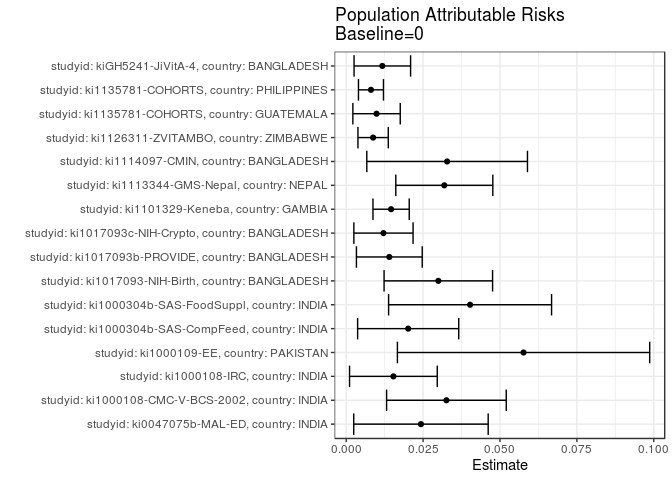

## Results Table

### Parameter: TSM

| studyid | country | intervention_level | baseline_level | estimate | ci_lower | ci_upper |
| --- | --- | --- | --- | --- | --- | --- |
| ki0047075b-MAL-ED | INDIA | 0 | NA | 0.0502513 | 0.0198316 | 0.0806709 |
| ki0047075b-MAL-ED | INDIA | 1 | NA | 0.2413793 | 0.0852926 | 0.3974660 |
| ki1000108-CMC-V-BCS-2002 | INDIA | 0 | NA | 0.0270270 | 0.0085283 | 0.0455257 |
| ki1000108-CMC-V-BCS-2002 | INDIA | 1 | NA | 0.1917808 | 0.1013445 | 0.2822172 |
| ki1000108-IRC | INDIA | 0 | NA | 0.0463768 | 0.0241583 | 0.0685953 |
| ki1000108-IRC | INDIA | 1 | NA | 0.1500000 | 0.0595384 | 0.2404616 |
| ki1000109-EE | PAKISTAN | 0 | NA | 0.1566228 | 0.1043859 | 0.2088597 |
| ki1000109-EE | PAKISTAN | 1 | NA | 0.3873240 | 0.2944603 | 0.4801876 |
| ki1000304b-SAS-CompFeed | INDIA | 0 | NA | 0.0815117 | 0.0642468 | 0.0987765 |
| ki1000304b-SAS-CompFeed | INDIA | 1 | NA | 0.2635622 | 0.1583607 | 0.3687637 |
| ki1000304b-SAS-FoodSuppl | INDIA | 0 | NA | 0.1435883 | 0.1000378 | 0.1871389 |
| ki1000304b-SAS-FoodSuppl | INDIA | 1 | NA | 0.3562226 | 0.2272146 | 0.4852305 |
| ki1017093-NIH-Birth | BANGLADESH | 0 | NA | 0.0804339 | 0.0534803 | 0.1073875 |
| ki1017093-NIH-Birth | BANGLADESH | 1 | NA | 0.3009907 | 0.1756134 | 0.4263681 |
| ki1017093b-PROVIDE | BANGLADESH | 0 | NA | 0.0513106 | 0.0322741 | 0.0703471 |
| ki1017093b-PROVIDE | BANGLADESH | 1 | NA | 0.2733366 | 0.1389635 | 0.4077098 |
| ki1017093c-NIH-Crypto | BANGLADESH | 0 | NA | 0.0336202 | 0.0185879 | 0.0486525 |
| ki1017093c-NIH-Crypto | BANGLADESH | 1 | NA | 0.1256937 | 0.0105558 | 0.2408317 |
| ki1101329-Keneba | GAMBIA | 0 | NA | 0.0417757 | 0.0320839 | 0.0514675 |
| ki1101329-Keneba | GAMBIA | 1 | NA | 0.2556952 | 0.1616063 | 0.3497840 |
| ki1113344-GMS-Nepal | NEPAL | 0 | NA | 0.0721119 | 0.0491164 | 0.0951074 |
| ki1113344-GMS-Nepal | NEPAL | 1 | NA | 0.3562479 | 0.2381323 | 0.4743634 |
| ki1114097-CMIN | BANGLADESH | 0 | NA | 0.0768844 | 0.0393294 | 0.1144394 |
| ki1114097-CMIN | BANGLADESH | 1 | NA | 0.2615064 | 0.1224843 | 0.4005285 |
| ki1126311-ZVITAMBO | ZIMBABWE | 0 | NA | 0.0446311 | 0.0344055 | 0.0548567 |
| ki1126311-ZVITAMBO | ZIMBABWE | 1 | NA | 0.2028399 | 0.1243543 | 0.2813256 |
| ki1135781-COHORTS | GUATEMALA | 0 | NA | 0.0389049 | 0.0245087 | 0.0533011 |
| ki1135781-COHORTS | GUATEMALA | 1 | NA | 0.2045455 | 0.0852789 | 0.3238120 |
| ki1135781-COHORTS | PHILIPPINES | 0 | NA | 0.0671333 | 0.0570711 | 0.0771955 |
| ki1135781-COHORTS | PHILIPPINES | 1 | NA | 0.2401657 | 0.1482875 | 0.3320440 |
| kiGH5241-JiVitA-4 | BANGLADESH | 0 | NA | 0.0840227 | 0.0721860 | 0.0958593 |
| kiGH5241-JiVitA-4 | BANGLADESH | 1 | NA | 0.3700751 | 0.2834497 | 0.4567006 |

### Parameter: E(Y)

| studyid | country | intervention_level | baseline_level | estimate | ci_lower | ci_upper |
| --- | --- | --- | --- | --- | --- | --- |
| ki0047075b-MAL-ED | INDIA | NA | NA | 0.0745614 | 0.0403897 | 0.1087331 |
| ki1000108-CMC-V-BCS-2002 | INDIA | NA | NA | 0.0596206 | 0.0354285 | 0.0838127 |
| ki1000108-IRC | INDIA | NA | NA | 0.0617284 | 0.0382610 | 0.0851958 |
| ki1000109-EE | PAKISTAN | NA | NA | 0.2142857 | 0.1712366 | 0.2573348 |
| ki1000304b-SAS-CompFeed | INDIA | NA | NA | 0.1016680 | 0.0902317 | 0.1131043 |
| ki1000304b-SAS-FoodSuppl | INDIA | NA | NA | 0.1838710 | 0.1406788 | 0.2270631 |
| ki1017093-NIH-Birth | BANGLADESH | NA | NA | 0.1103896 | 0.0817833 | 0.1389959 |
| ki1017093b-PROVIDE | BANGLADESH | NA | NA | 0.0653358 | 0.0446834 | 0.0859881 |
| ki1017093c-NIH-Crypto | BANGLADESH | NA | NA | 0.0457413 | 0.0294659 | 0.0620168 |
| ki1101329-Keneba | GAMBIA | NA | NA | 0.0563781 | 0.0455871 | 0.0671692 |
| ki1113344-GMS-Nepal | NEPAL | NA | NA | 0.1040146 | 0.0784316 | 0.1295976 |
| ki1114097-CMIN | BANGLADESH | NA | NA | 0.1097046 | 0.0698323 | 0.1495770 |
| ki1126311-ZVITAMBO | ZIMBABWE | NA | NA | 0.0533893 | 0.0425943 | 0.0641843 |
| ki1135781-COHORTS | GUATEMALA | NA | NA | 0.0487805 | 0.0332288 | 0.0643322 |
| ki1135781-COHORTS | PHILIPPINES | NA | NA | 0.0751910 | 0.0648251 | 0.0855569 |
| kiGH5241-JiVitA-4 | BANGLADESH | NA | NA | 0.0957734 | 0.0852493 | 0.1062974 |

### Parameter: RR

| studyid | country | intervention_level | baseline_level | estimate | ci_lower | ci_upper |
| --- | --- | --- | --- | --- | --- | --- |
| ki0047075b-MAL-ED | INDIA | 0 | 0 | 1.000000 | 1.000000 | 1.000000 |
| ki0047075b-MAL-ED | INDIA | 1 | 0 | 4.803448 | 1.980913 | 11.647715 |
| ki1000108-CMC-V-BCS-2002 | INDIA | 0 | 0 | 1.000000 | 1.000000 | 1.000000 |
| ki1000108-CMC-V-BCS-2002 | INDIA | 1 | 0 | 7.095890 | 3.090539 | 16.292192 |
| ki1000108-IRC | INDIA | 0 | 0 | 1.000000 | 1.000000 | 1.000000 |
| ki1000108-IRC | INDIA | 1 | 0 | 3.234375 | 1.497241 | 6.986971 |
| ki1000109-EE | PAKISTAN | 0 | 0 | 1.000000 | 1.000000 | 1.000000 |
| ki1000109-EE | PAKISTAN | 1 | 0 | 2.472974 | 1.636297 | 3.737463 |
| ki1000304b-SAS-CompFeed | INDIA | 0 | 0 | 1.000000 | 1.000000 | 1.000000 |
| ki1000304b-SAS-CompFeed | INDIA | 1 | 0 | 3.233429 | 1.961895 | 5.329064 |
| ki1000304b-SAS-FoodSuppl | INDIA | 0 | 0 | 1.000000 | 1.000000 | 1.000000 |
| ki1000304b-SAS-FoodSuppl | INDIA | 1 | 0 | 2.480860 | 1.545673 | 3.981868 |
| ki1017093-NIH-Birth | BANGLADESH | 0 | 0 | 1.000000 | 1.000000 | 1.000000 |
| ki1017093-NIH-Birth | BANGLADESH | 1 | 0 | 3.742088 | 2.192045 | 6.388198 |
| ki1017093b-PROVIDE | BANGLADESH | 0 | 0 | 1.000000 | 1.000000 | 1.000000 |
| ki1017093b-PROVIDE | BANGLADESH | 1 | 0 | 5.327100 | 2.880711 | 9.851040 |
| ki1017093c-NIH-Crypto | BANGLADESH | 0 | 0 | 1.000000 | 1.000000 | 1.000000 |
| ki1017093c-NIH-Crypto | BANGLADESH | 1 | 0 | 3.738639 | 1.349781 | 10.355321 |
| ki1101329-Keneba | GAMBIA | 0 | 0 | 1.000000 | 1.000000 | 1.000000 |
| ki1101329-Keneba | GAMBIA | 1 | 0 | 6.120667 | 3.965249 | 9.447721 |
| ki1113344-GMS-Nepal | NEPAL | 0 | 0 | 1.000000 | 1.000000 | 1.000000 |
| ki1113344-GMS-Nepal | NEPAL | 1 | 0 | 4.940210 | 3.111001 | 7.844961 |
| ki1114097-CMIN | BANGLADESH | 0 | 0 | 1.000000 | 1.000000 | 1.000000 |
| ki1114097-CMIN | BANGLADESH | 1 | 0 | 3.401292 | 1.653869 | 6.994986 |
| ki1126311-ZVITAMBO | ZIMBABWE | 0 | 0 | 1.000000 | 1.000000 | 1.000000 |
| ki1126311-ZVITAMBO | ZIMBABWE | 1 | 0 | 4.544813 | 2.899415 | 7.123962 |
| ki1135781-COHORTS | GUATEMALA | 0 | 0 | 1.000000 | 1.000000 | 1.000000 |
| ki1135781-COHORTS | GUATEMALA | 1 | 0 | 5.257576 | 2.635527 | 10.488263 |
| ki1135781-COHORTS | PHILIPPINES | 0 | 0 | 1.000000 | 1.000000 | 1.000000 |
| ki1135781-COHORTS | PHILIPPINES | 1 | 0 | 3.577444 | 2.372224 | 5.394984 |
| kiGH5241-JiVitA-4 | BANGLADESH | 0 | 0 | 1.000000 | 1.000000 | 1.000000 |
| kiGH5241-JiVitA-4 | BANGLADESH | 1 | 0 | 4.404468 | 3.378616 | 5.741801 |

### Parameter: PAR

| studyid | country | intervention_level | baseline_level | estimate | ci_lower | ci_upper |
| --- | --- | --- | --- | --- | --- | --- |
| ki0047075b-MAL-ED | INDIA | 0 | NA | 0.0243101 | 0.0024528 | 0.0461675 |
| ki1000108-CMC-V-BCS-2002 | INDIA | 0 | NA | 0.0325936 | 0.0131397 | 0.0520475 |
| ki1000108-IRC | INDIA | 0 | NA | 0.0153516 | 0.0010923 | 0.0296108 |
| ki1000109-EE | PAKISTAN | 0 | NA | 0.0576630 | 0.0166541 | 0.0986718 |
| ki1000304b-SAS-CompFeed | INDIA | 0 | NA | 0.0201563 | 0.0037184 | 0.0365942 |
| ki1000304b-SAS-FoodSuppl | INDIA | 0 | NA | 0.0402826 | 0.0137912 | 0.0667740 |
| ki1017093-NIH-Birth | BANGLADESH | 0 | NA | 0.0299557 | 0.0123174 | 0.0475940 |
| ki1017093b-PROVIDE | BANGLADESH | 0 | NA | 0.0140252 | 0.0033303 | 0.0247201 |
| ki1017093c-NIH-Crypto | BANGLADESH | 0 | NA | 0.0121211 | 0.0024962 | 0.0217461 |
| ki1101329-Keneba | GAMBIA | 0 | NA | 0.0146024 | 0.0087062 | 0.0204987 |
| ki1113344-GMS-Nepal | NEPAL | 0 | NA | 0.0319027 | 0.0161316 | 0.0476739 |
| ki1114097-CMIN | BANGLADESH | 0 | NA | 0.0328202 | 0.0067042 | 0.0589363 |
| ki1126311-ZVITAMBO | ZIMBABWE | 0 | NA | 0.0087582 | 0.0038261 | 0.0136903 |
| ki1135781-COHORTS | GUATEMALA | 0 | NA | 0.0098756 | 0.0021738 | 0.0175774 |
| ki1135781-COHORTS | PHILIPPINES | 0 | NA | 0.0080577 | 0.0039933 | 0.0121221 |
| kiGH5241-JiVitA-4 | BANGLADESH | 0 | NA | 0.0117507 | 0.0025605 | 0.0209409 |

### Parameter: PAF

| studyid | country | intervention_level | baseline_level | estimate | ci_lower | ci_upper |
| --- | --- | --- | --- | --- | --- | --- |
| ki0047075b-MAL-ED | INDIA | 0 | NA | 0.3260420 | 0.0132207 | 0.5396950 |
| ki1000108-CMC-V-BCS-2002 | INDIA | 0 | NA | 0.5466830 | 0.2215195 | 0.7360290 |
| ki1000108-IRC | INDIA | 0 | NA | 0.2486956 | 0.0026326 | 0.4340518 |
| ki1000109-EE | PAKISTAN | 0 | NA | 0.2690938 | 0.0565032 | 0.4337830 |
| ki1000304b-SAS-CompFeed | INDIA | 0 | NA | 0.1982564 | 0.0247700 | 0.3408808 |
| ki1000304b-SAS-FoodSuppl | INDIA | 0 | NA | 0.2190810 | 0.0680668 | 0.3456243 |
| ki1017093-NIH-Birth | BANGLADESH | 0 | NA | 0.2713635 | 0.1089285 | 0.4041878 |
| ki1017093b-PROVIDE | BANGLADESH | 0 | NA | 0.2146630 | 0.0496949 | 0.3509934 |
| ki1017093c-NIH-Crypto | BANGLADESH | 0 | NA | 0.2649932 | 0.0467994 | 0.4332410 |
| ki1101329-Keneba | GAMBIA | 0 | NA | 0.2590088 | 0.1594411 | 0.3467823 |
| ki1113344-GMS-Nepal | NEPAL | 0 | NA | 0.3067138 | 0.1583904 | 0.4288971 |
| ki1114097-CMIN | BANGLADESH | 0 | NA | 0.2991689 | 0.0448488 | 0.4857734 |
| ki1126311-ZVITAMBO | ZIMBABWE | 0 | NA | 0.1640448 | 0.0725072 | 0.2465483 |
| ki1135781-COHORTS | GUATEMALA | 0 | NA | 0.2024496 | 0.0431095 | 0.3352566 |
| ki1135781-COHORTS | PHILIPPINES | 0 | NA | 0.1071627 | 0.0535632 | 0.1577267 |
| kiGH5241-JiVitA-4 | BANGLADESH | 0 | NA | 0.1226929 | 0.0245639 | 0.2109502 |